# Systems Genomics

Author

Julia Frank, Masja Hoogendoorn, Zoe Marolf

Published

December 2, 2024

## **Load packages**

```r
library(ggplot2)
library(pheatmap)
library(dplyr)
library(tidyr)
library(DESeq2)
```

## Overview data

- L1 stage larvae: SRR1197426 = L1.1, SRR1197325 = L1.2
- L2 stage larvae: SRR1197425 = L2.1, SRR1197324 = L2.2
- L3 stage larvae: SRR1197424 = L3.1, SRR1197326 = L3.2
- pupae, WPP + 2 days: SRR1197420 = P1.1, SRR1197287 = P1.2
- pupae, WPP + 3 days: SRR1197419 = P2.1, SRR1197285 = P2.2
- pupae, WPP + 4 days: SRR1197416 = P3.1, SRR1197286 = P3.2

## 1. Load data

### 1.1 Load the .genes.results into dataframes

```r
# Define file names and corresponding column labels
dataset_labels <- list(L1.1 = "SRR1197426", L1.2 = "SRR1197325",
                       L2.1 = "SRR1197425", L2.2 = "SRR1197324",
                       L3.1 = "SRR1197424", L3.2 = "SRR1197326",
                       P1.1 = "SRR1197420", P1.2 = "SRR1197287",
                       P2.1 = "SRR1197419", P2.2 = "SRR1197285",
                       P3.1 = "SRR1197416", P3.2 = "SRR1197286")

# Function to load and merge gene results
load_and_merge_gene_results <- function(folder, file_labels, column_name = "expected_count") {
  datasets <- lapply(names(file_labels), function(label) {
    file_path <- paste0(folder, "/", file_labels[[label]], ".genes.results")
    # Extract gene_id and specified column for each dataset
    data <- read.table(file_path, header = TRUE)[, c("gene_id", column_name)]
    colnames(data)[2] <- label
    return(data)
  })
  # Merge all datasets on gene_id
  merged_data <- Reduce(function(x, y) merge(x, y, by = "gene_id", all = TRUE), datasets)
  return(merged_data)
}

# Load and merge datasets for refGene (Masja's version) and ncbiRefSeq (Julia's version) annotations
RSEM_counts_refGene <- load_and_merge_gene_results("RSEM_refGene", dataset_labels, "expected_count")
RSEM_counts_ncbiRefSeq <- load_and_merge_gene_results("RSEM_NCBI", dataset_labels, "expected_count")

# Load and merge datasets for TPM values
RSEM_TPM_refGene <- load_and_merge_gene_results("RSEM_refGene", dataset_labels, "TPM")
RSEM_TPM_ncbiRefSeq <- load_and_merge_gene_results("RSEM_NCBI", dataset_labels, "TPM")
```

### 1.2 Load the .isoforms.results into dataframes

```r
# Creates a table with transcript_id and expected_count of all isoforms
load_and_merge_isoforms <- function(folder, file_labels) {
  datasets <- lapply(names(file_labels), function(label) {
    file_path <- paste0(folder, "/", file_labels[[label]], ".isoforms.results")

    # Read the isoform-level data
    data <- read.table(file_path, header = TRUE)

    # Select transcript_id and expected_count columns for each dataset
    data <- data[, c("transcript_id", "expected_count")]

    # Rename the second column to the dataset label for clarity
    colnames(data)[2] <- label
    return(data)
  })

  # Merge all datasets on transcript_id (for isoform-level data)
  merged_data <- Reduce(function(x, y) merge(x, y, by = "transcript_id", all = TRUE), datasets)
  return(merged_data)
}

# Load and merge isoform-level datasets for both refGene and ncbiRefSeq annotations
RSEM_isoforms_refGene <- load_and_merge_isoforms("RSEM_refGene", dataset_labels)
RSEM_isoforms_ncbiRefSeq <- load_and_merge_isoforms("RSEM_NCBI", dataset_labels)
```

### 1.4 Load additional information about genes

```r
# Load biomaRt library
library(biomaRt)

# Specify Ensembl mart and dataset for Drosophila melanogaster
ensembl <- useEnsembl(biomart = "ensembl",
                      dataset = "dmelanogaster_gene_ensembl")
```

```
Ensembl site unresponsive, trying useast mirror
```

```
Ensembl site unresponsive, trying asia mirror
```

```r
# List all available attributes
list_attributes <- listAttributes(ensembl)

# View the first few rows of attributes
list_filters <- listFilters(ensembl)
View(list_filters)

head(RSEM_TPM_ncbiRefSeq$gene_id)
```

```
[1] "128up"               "14-3-3epsilon"       "14-3-3zeta"
[4] "140up"               "18SrRNA-Psi:CR41602" "18SrRNA-Psi:CR45861"
```

```r
# Retrieve metadata for your dataset using with_entrezgene
meta_genes <- getBM(attributes = c("ensembl_gene_id",
                                   "external_gene_name",
                                   "description",
                                   "chromosome_name",
                                   "start_position",
                                   "end_position",
                                   "strand"),
                    filters = "external_synonym",
                    values = RSEM_TPM_ncbiRefSeq$gene_id,
                    mart = ensembl)

# Merge metadata with the RSEM_TPM_ncbiRefSeq dataframe
RSEM_TPM_ncbiRefSeq_annotated <- merge(
  RSEM_TPM_ncbiRefSeq,
  meta_genes,
  by.x = "gene_id",  # Match on gene_id from your dataframe
  by.y = "external_gene_name",  # Match on external_gene_name from Ensembl
  all.x = TRUE  # Keep all rows from the original dataframe
)

# Reorder columns to place metadata after gene_id
RSEM_TPM_ncbiRefSeq_annotated <- RSEM_TPM_ncbiRefSeq_annotated[, c(
  "gene_id",  # Keep gene_id first
  "ensembl_gene_id", "description", "chromosome_name", "start_position", "end_position", "strand",  # Metadata columns
  setdiff(colnames(RSEM_TPM_ncbiRefSeq_annotated), c("gene_id", "ensembl_gene_id", "description", "chromosome_name", "start_position", "end_position", "strand"))  # Remaining columns
)]

# View the annotated dataframe
View(RSEM_TPM_ncbiRefSeq_annotated)
```

## 2. Annotations

- **refGene (Masja):** only the curated subset of RefSeq (UCSC)
- **ncbiRefSeq (Julia):** complete (curated+predicted) RefSeq database of NCBI –> we decided to only use the ncbi data

## 3 Analysis following the tutorial

### 3.1 Comparison of transcriptomic profiles across samples

#### Tutorial page 54

*Conclusion:*

The histogram on the left shows that most genes have very low average expression, with a few outliers exhibiting extremely high expression levels, leading to a highly skewed distribution. The log-transformed histogram on the right reveals a more normalized distribution, indicating that log transformation effectively reduces the impact of extreme values and highlights the variation among low and moderately expressed genes. **This transformation is essential for downstream analyses to prevent dominance by highly expressed genes.**

```r
# Calculate the average expression across all samples
expr <- RSEM_TPM_ncbiRefSeq
rownames(expr) <- expr$gene_id  # Set 'gene_id' as row names
expr <- expr[, -1]  # Remove the 'gene_id' column
avg_expr <- rowMeans(expr, na.rm = TRUE)
summary(avg_expr)
```

```
     Min.   1st Qu.    Median      Mean   3rd Qu.      Max.
     0.00      0.35      2.11     55.97      6.56 120411.83
```

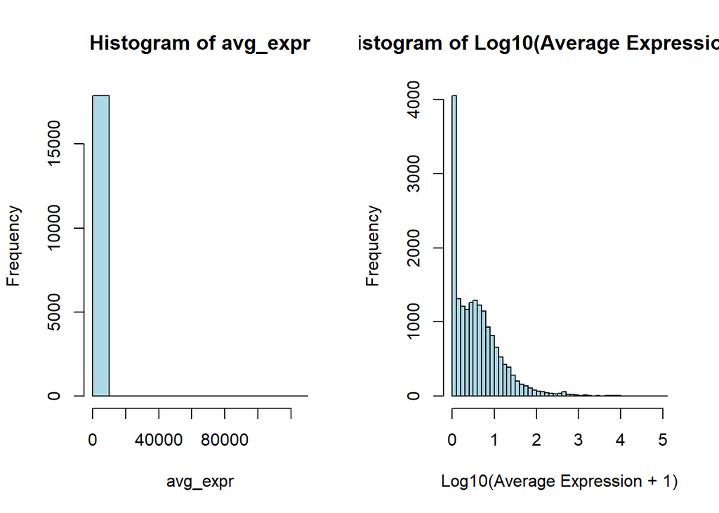

```r
# Plot histograms
layout(matrix(1:2, nrow = 1))  # Arrange plots side by side
# First histogram: Adjust x-axis range to focus on lower expression values
hist(avg_expr, col = "lightblue")

# Second histogram: Log-transformed, as before
hist(log10(avg_expr + 1),
     breaks = 50,  # Increase bins for better resolution
     main = "Histogram of Log10(Average Expression + 1)",
     xlab = "Log10(Average Expression + 1)",
     col = "lightblue",
     border = "black")
```

#### Tutorial page 55

*Conclusion:*

This histogram shows the distribution of average expression values on log-log scales, revealing a gradual decrease in frequency as expression values increase. The log transformation effectively highlights the range of expression levels, from low to high, while emphasizing the presence of many lowly expressed genes and fewer highly expressed ones. This indicates that most genes exhibit low to moderate expression, with a minority of genes showing high expression levels.

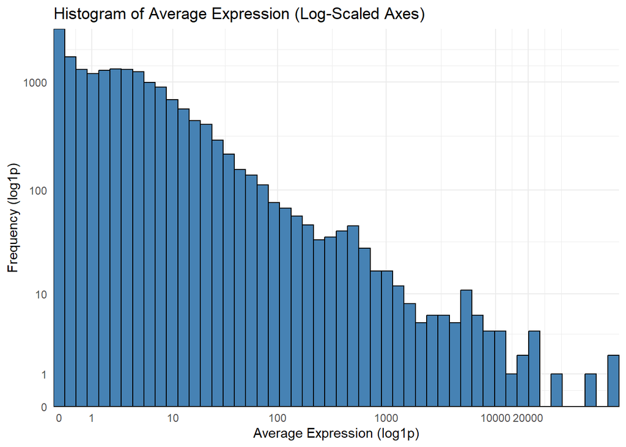

```r
# Load ggplot2 library
library(ggplot2)

# Create a dataframe from avg_expr
avg_expr_df <- data.frame(avg_expr)

# Generate the histogram
ggplot(avg_expr_df, aes(x = avg_expr)) +
  geom_histogram(bins = 50, fill = "steelblue", color = "black") +  # Adjust color for better readability
  scale_x_continuous(
    breaks = c(0, 1, 10, 100, 1000, 10000, 20000),  # Custom breaks on the x-axis
    trans = "log1p",                                # Log1p transformation for x-axis
    expand = c(0, 0)                                # No padding on x-axis
  ) +
  scale_y_continuous(
    breaks = c(0, 1, 10, 100, 1000),               # Custom breaks on the y-axis
    trans = "log1p",                                # Log1p transformation for y-axis
    expand = c(0, 0)                                # No padding on y-axis
  ) +
  theme_minimal() +
  labs(
    title = "Histogram of Average Expression (Log-Scaled Axes)",
    x = "Average Expression (log1p)",
    y = "Frequency (log1p)"
  )
```

#### Tutorial page 56

*Conclusion:*

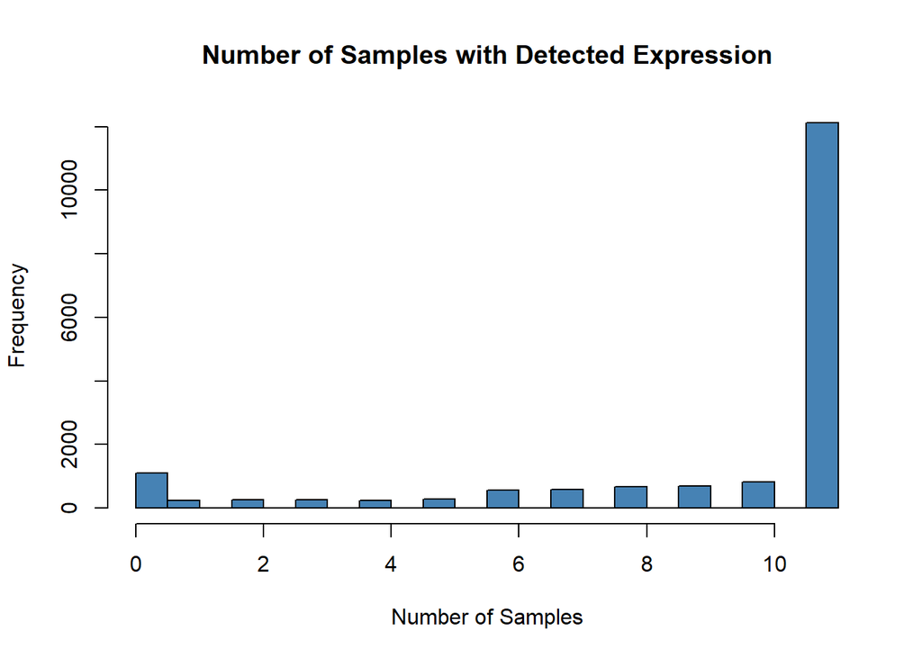

```r
# Calculate the number of samples where expression is greater than 0
num_det <- rowSums(expr[, -1] > 0)

# Create a histogram to visualize the distribution
hist(
  num_det,
  col = "steelblue",  # Add color for better readability
  border = "black",
  main = "Number of Samples with Detected Expression",
  xlab = "Number of Samples",
  ylab = "Frequency"
)
```

#### Tutorial page 57

*Conclusion:*

We add a column ‘expressed’ to the dataframe. If we filter genes out with low expression (only select expression == TRUE), the dataset reduces to **15,565 retained genes**, while **2,303 genes are removed**, as shown below:

```r
# Calculate expressed genes based on your criteria
expressed_genes <- rowMeans(expr[, -1] > 0) >= 0.5 | rowMeans(expr) >= 1

# Count the number of retained and removed genes
num_retained <- sum(expressed_genes)  # Genes retained
num_removed <- sum(!expressed_genes) # Genes removed

# Output the counts
cat("Number of genes retained:", num_retained, "\n")
```

```
Number of genes retained: 15565
```

```r
cat("Number of genes removed:", num_removed, "\n")
```

```
Number of genes removed: 2303
```

```r
# Add the expressed column to the annotated dataframe if needed
RSEM_TPM_ncbiRefSeq_annotated$expressed <- expressed_genes

# View the updated metadata with the expressed column
head(RSEM_TPM_ncbiRefSeq_annotated)
```

```
              gene_id ensembl_gene_id                          description
1               128up     FBgn0010339                 upstream of RpIII128
2       14-3-3epsilon     FBgn0020238                        14-3-3epsilon
3          14-3-3zeta     FBgn0004907                           14-3-3zeta
4               140up     FBgn0010340                  upstream of RpII140
5 18SrRNA-Psi:CR41602     FBgn0085813 18S ribosomal RNA pseudogene:CR41602
6 18SrRNA-Psi:CR45861     FBgn0267521 18S ribosomal RNA pseudogene:CR45861
  chromosome_name start_position end_position strand   L1.1   L1.2   L2.1
1              2R       12037298     12038851      1  23.89  22.66  21.37
2              3R       18242531     18250550      1 104.52 116.93 126.06
3              2R       10099677     10109687      1 396.75 426.02 373.35
4              3R       14124163     14125548     -1   7.06   5.75   8.93
5               X       23211192     23213166      1   0.25   0.65   0.33
6               X       23280998     23282931     -1   0.46   1.01   0.24
    L2.2   L3.1   L3.2   P1.1   P1.2   P2.1   P2.2   P3.1   P3.2 expressed
1  24.87  13.28  23.88   7.68   8.98   7.17   6.17   6.00   4.67      TRUE
2 131.89  95.11 139.65  91.35 109.99  55.49  63.71  63.52  49.50      TRUE
3 386.02 282.82 425.35 179.69 217.48 266.92 299.35 300.18 227.75      TRUE
4   8.79   5.79   9.26   3.66   3.51   4.86   5.21   2.97   2.75      TRUE
5   1.19   0.26   0.94   1.98   7.53   2.31   4.69   3.02  17.93      TRUE
6   1.19   0.15   1.28   7.73  26.63   6.04  25.13   4.47  29.55      TRUE
```

#### Tutorial page 58

*Conclusion:*

The dendrograms reveal distinct clustering of larval and pupal stages, reflecting stage-specific gene expression patterns during Drosophila development. **Sub-clusters within each stage (L and P) indicate gradual changes in gene expression corresponding to different time points or developmental phases.** This suggests tightly regulated transcriptional programs driving the transition from larval growth to pupal metamorphosis.

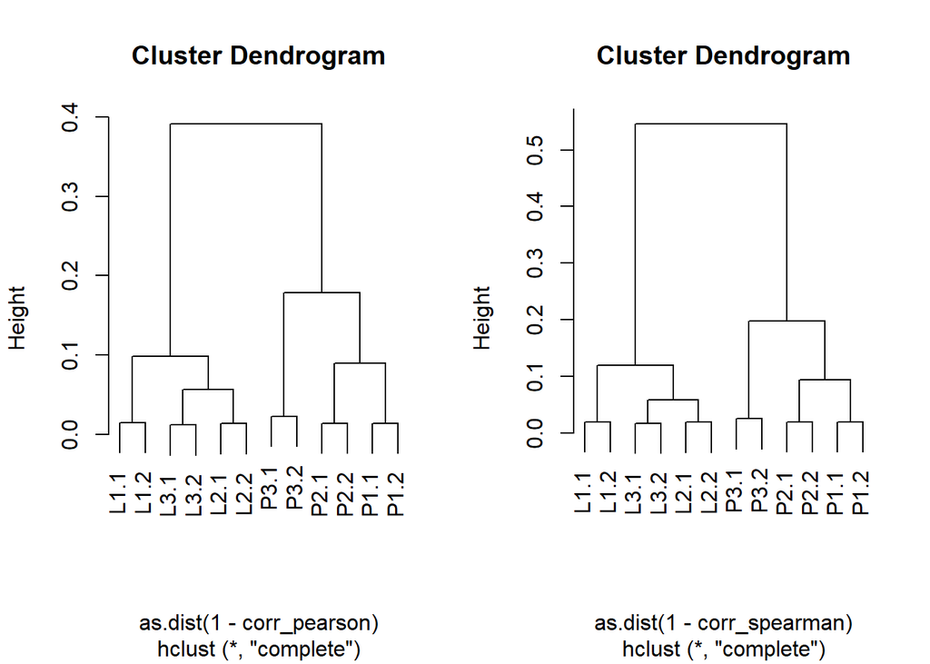

```r
corr_pearson <- cor(log1p(expr[RSEM_TPM_ncbiRefSeq_annotated$expressed,]))
corr_spearman <- cor(expr[RSEM_TPM_ncbiRefSeq_annotated$expressed,], method = "spearman")

hcl_pearson <- hclust(as.dist(1 - corr_pearson))
hcl_spearman <- hclust(as.dist(1 - corr_spearman))

layout(matrix(1:2,nrow=1))
plot(hcl_pearson)
plot(hcl_spearman)
```

#### Tutorial page 59

*Conclusion:* The plot clearly distinguishes between the larvae (L) and pupae (P) stages using color and differentiates individuals using shapes. The data shows distinct clustering of the stages, with some overlap between individuals within the same stage, suggesting some variation within each group. Further investigation may be needed to explore the relationships between individual samples and their positioning along the principal components.

```r
dim(expr)  # Should return (samples x genes) if not using transpose
```

```
[1] 17868    12
```

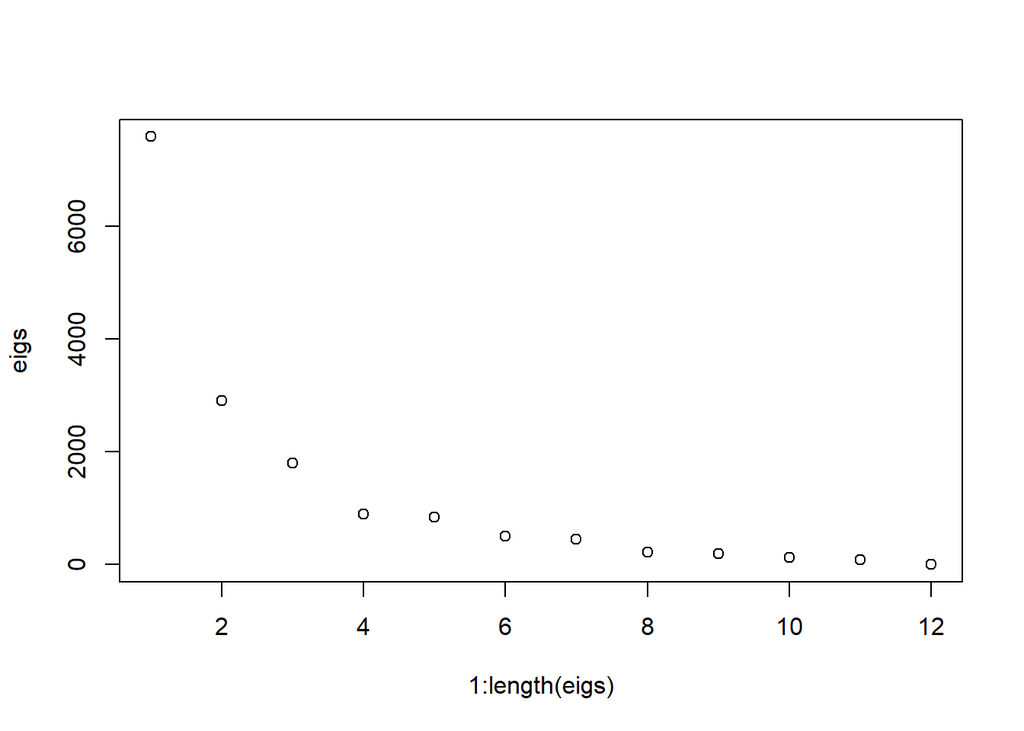

```r
pca <- prcomp(log1p(t(expr[RSEM_TPM_ncbiRefSeq_annotated$expressed,])), center = TRUE, scale. = TRUE)
eigs <- pca$sdev^2
plot(1:length(eigs), eigs)
```

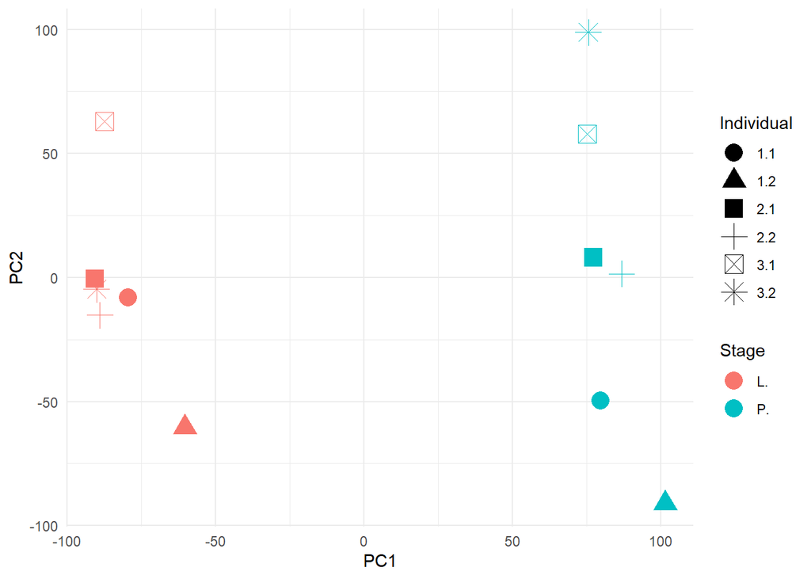

```r
# Assuming your data is stored in pca$x and you want to add Stage and Individual
library(dplyr)

# Create a data frame for plotting
pca_data <- data.frame(pca$x)

# Extract Stage and Individual from the row names
pca_data$Stage <- gsub("\\d", "", rownames(pca_data))  # Extract "L", "P", etc.
pca_data$Individual <- gsub("[A-Za-z]", "", rownames(pca_data))  # Extract "1", "2", etc.

library(ggplot2)

ggplot(pca_data) +
  geom_point(aes(x = PC1, y = PC2, color = Stage, shape = Individual), size = 5) +
  labs(color = "Stage", shape = "Individual") +
  theme_minimal()
```

## 4 Own Analysis

### 4.1 Heatmap expression levels

Made by: Masja

```r
# Article about the normalization step
#https://bioinfo.cd-genomics.com/resource-data-normalization-for-rna-seq-and-heatmaps.html#:~:text=Heatmap%20Data%20Normalization,-Heatmaps%20provide%20a&text=The%20resulting%20Z%2Dscore%20scaling,(usually%20shown%20in%20blue).

head(RSEM_counts_ncbiRefSeq)
```

```
              gene_id     L1.1     L1.2     L2.1     L2.2     L3.1     L3.2
1               128up  2257.00  1895.00  1893.00  2205.00  1286.00  2166.00
2       14-3-3epsilon 15114.00 15927.00 14969.00 15904.00 11874.00 16182.00
3          14-3-3zeta 50729.00 49963.00 42745.00 44027.00 33470.00 47301.00
4               140up   466.32   351.46   557.15   571.91   393.30   588.20
5 18SrRNA-Psi:CR41602    38.67    86.69    46.89   168.78    40.25   135.56
6 18SrRNA-Psi:CR45861    68.52   132.02    33.19   165.21    22.69   181.58
      P1.1     P1.2     P2.1     P2.2     P3.1     P3.2
1   306.00   272.00   255.00   238.00   293.00   141.00
2  5190.00  5065.00  2893.00  3937.00  4364.00  2295.00
3 10804.00 10655.00 14173.00 19317.00 20732.00 10758.00
4   109.58    87.00   121.54   156.22   107.70    63.39
5   125.72   361.26   131.00   287.00   236.22   861.34
6   480.32  1248.44   335.40  1503.55   341.42  1387.73
```

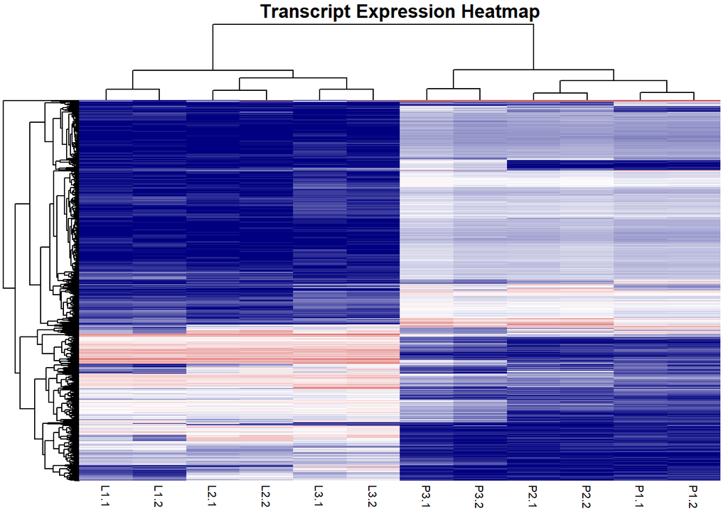

```r
# Log transform the numeric columns (excluding 'gene_id')
RSEM_counts_log <- log2(RSEM_counts_ncbiRefSeq[, -1] + 1)  # Apply log2 transformation


# Calculate variance for each gene and filter the top 10% most variable genes
gene_variances <- apply(RSEM_counts_log, 1, var)  # Calculate variance row-wise
top_variable_genes <- RSEM_counts_log[order(-gene_variances)[1:floor(0.1 * nrow(RSEM_counts_log))], ]

# Create an enhanced clustered heatmap
library(pheatmap)

pheatmap(
  as.matrix(top_variable_genes),
  color = colorRampPalette(c("navy", "white", "firebrick3"))(100),
  cluster_rows = TRUE,  # Cluster rows for better grouping
  cluster_cols = TRUE,  # Cluster columns (retain this)
  # scale = "row", # z-score normalization by row (IMPORTANT!)
  show_rownames = FALSE,
  show_colnames = TRUE,
  fontsize_row = max(6, 0.2 * nrow(top_variable_genes)),  # Adjust font size based on data
  fontsize_col = 8,
  legend = FALSE,  # Optionally hide legend if unnecessary
  border_color = NA,  # Remove gridlines for cleaner look
  main = "Transcript Expression Heatmap"
)
```

## Differential Expression Analysis

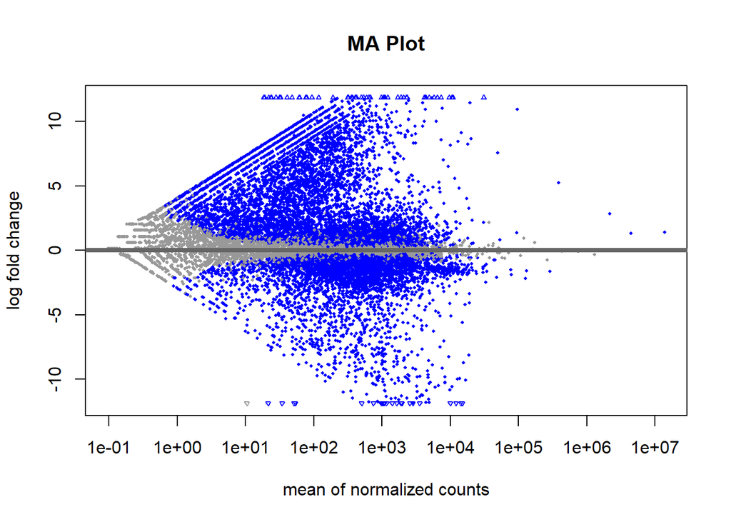

```r
# Prepare the count matrix and metadata
count_matrix <- RSEM_counts_ncbiRefSeq
rownames(count_matrix) <- count_matrix$gene_id
count_matrix <- count_matrix[,-1] # Remove gene_id column

# Round non-integer values to integers
count_matrix <- round(as.matrix(count_matrix))

# Define metadata
col_data <- data.frame(
  sample = colnames(count_matrix),
  condition = rep(c("L", "P"), each = 6),
  replicate = rep(1:3, each = 2, times = 2),
  row.names = colnames(count_matrix)
)

# Create DESeq2 dataset
dds <- DESeqDataSetFromMatrix(countData = count_matrix,
                              colData = col_data,
                              design = ~ condition)
# Pre-filter low counts
dds <- dds[rowSums(counts(dds)) > 1, ]

# Run DESeq2 differential expression analysis
dds <- DESeq(dds)
# Extract results
res <- results(dds)

# Apply Benjamini-Hochberg correction for multiple testing
res$padj <- p.adjust(res$pvalue, method = "BH")

# Apply Log2 Fold Change threshold (e.g., |log2FoldChange| > 1)
logFC_threshold <- 1
res$significant <- ifelse(abs(res$log2FoldChange) > logFC_threshold & res$padj < 0.05, "Significant", "Not Significant")

# Visualize results
# 1. MA Plot
plotMA(res, main = "MA Plot")
```

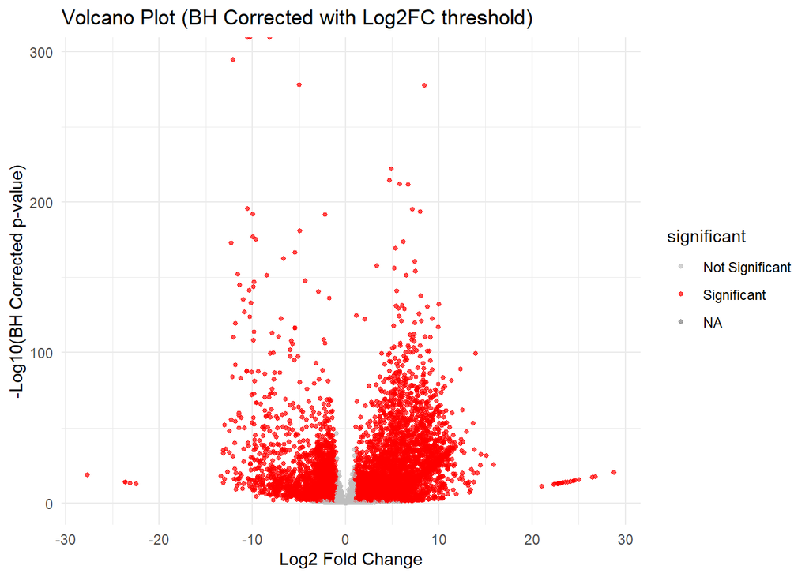

```r
# 2. Visualize with volcano plot
res_df <- as.data.frame(res)
res_df$gene <- rownames(res_df)

ggplot(res_df, aes(x = log2FoldChange, y = -log10(padj))) +
  geom_point(aes(color = significant), alpha = 0.7, size = 1) +
  scale_color_manual(values = c("gray", "red")) +
  theme_minimal() +
  labs(
    title = "Volcano Plot (BH Corrected with Log2FC threshold)",
    x = "Log2 Fold Change",
    y = "-Log10(BH Corrected p-value)"
  )
```

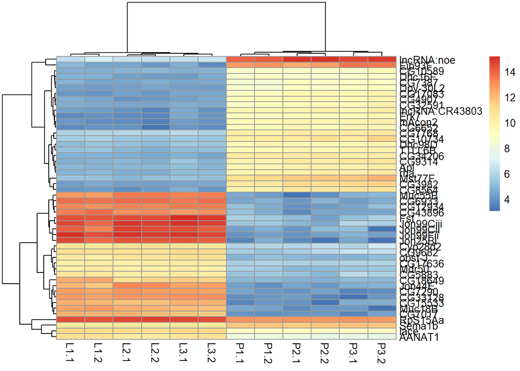

```r
# 3. Heatmap of top differentially expressed genes based on Log2 Fold Change and p-value
top_genes <- rownames(res[order(res$padj),])[abs(res$log2FoldChange) > logFC_threshold]
top_genes <- top_genes[1:50]  # Select top 50 genes after applying log2FC threshold
normalized_counts <- assay(vst(dds, blind = FALSE))  # Variance stabilizing transformation
pheatmap(normalized_counts[top_genes, ], cluster_rows = TRUE, cluster_cols = TRUE)
```